# Sprawozdanie 2

Adrian Pilarczyk i Diana Popiel

Matematyka Stosowana

## Zadanie 1.

Treść:

Firma A produkuje telefony komórkowe. Na pudełku nowego modelu S firmy A widnieje napis, że bateria wytrzymuje średnio 48 godzin. Nie uwierzyliśmy firmie A i zostawiliśmy na 42 różnych telefonach modelu S włączone wideo tak długo, aż się rozładowały. W pliku zad2.csv znajdują się dane zebrane przez nas podczas tego eksperymentu. Uzasadnij, że możesz użyć testu t i użyj testu t, aby zweryfikować, czy firma A nie okłamuje konsumentów.

Rozwiązanie:

Test t-Studenta jest testem parametrycznym. Aby go użyć, powinniśmy zadbać, aby nasze dane:

- były wybierane z jednej populacji,
- były od siebie niezależne,
- wartości powinny być przybliżone do rozkładu normalnego.

W treści zadania widzimy, że mamy 42 różnych telefonów modelu S. Możemy z tego wnioskować, że telefony został wylosowane z konkretnej populacji. Dodatkowo każda wytrzymałość baterii telefonu jest niezależna od innych. Pozostało nam tylko sprawdzić, czy podane wartości przybliżają rozkład normalny.

Aby to sprawdzić, możemy wykonać wykres QQ-plot oraz test Shapiro-Wilka:

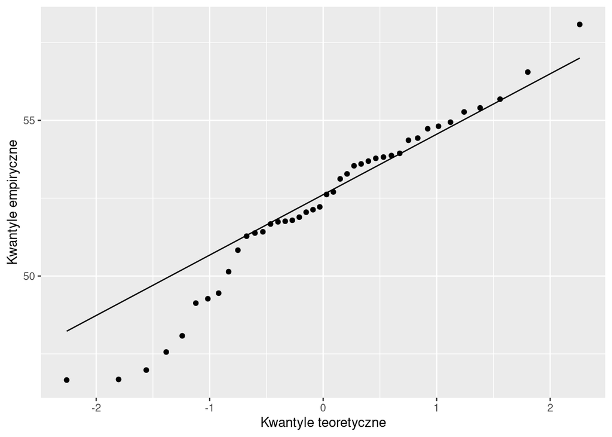

```r
normal_sample <- tibble(sample = zad2$durability)
qqplot_durability <- ggplot(data=normal_sample, aes(sample=sample)) + stat_qq() + geom_qq_line() + xlab('Kwantyle teoretyczne') + ylab('Kwantyle empiryczne')
qqplot_durability
```

Z podanego wykresu możemy wywnioskować, że większość wartości zbliża się do wykresu prostej y=x, co sugeruję, że rozkład danych jest zbliżony do rozkładu normalnego. Jednak widzimy, że parę punktów odstaję od reszty. Aby potwierdzić naszą hipotezę o normalności danych, przeprowadzamy test Shapiro-Wilka. Zakładamy poziom istotności na poziomie $\alpha = 0.05$:

```r
shapiro.test(zad2$durability)
```

```
##
##  Shapiro-Wilk normality test
##
## data:  zad2$durability
## W = 0.96515, p-value = 0.2249
```

Z danych wyjściowych testu wartość $p-value > 0,05$, gdzie $0,05$ jest założonym poziomem istotności $\alpha$, oznacza, że rozkład danych nie różni się istotnie od rozkładu normalnego. Innymi słowy, możemy założyć normalność danych.

Dzięki temu mamy słuszność, aby użyć testu t-Studenta na naszych danych i przeprowadzić naszą hipotezę. Załózmy, że prawdziwa średnia wytrzymałośc baterii w telefonie wynosi $\mu =48$. Tworzymy twierdzenie, że:

- hipoteza zerowa $H_0:\mu=48$,
- hipoteza alternatywna $H_1:\mu\neq48$.

Sprawdzamy je, używając testu t-Studenta:

```r
t.test(zad2$durability, mu=48)
```

```
##
##  One Sample t-test
##
## data:  zad2$durability
## t = 10.35, df = 41, p-value = 5.301e-13
## alternative hypothesis: true mean is not equal to 48
## 95 percent confidence interval:
##  51.45556 53.13110
## sample estimates:
## mean of x
##  52.29333
```

Wynik testu pokazuję nam, że:

- “p-value = 5.301e-13” - $p-value<0.05$ zatem istnieje istotna różnica między średnią wytrzymałością baterii a deklarowaną wartością,
- “alternative hypothesis: true mean is not equal to $48$” - odrzuciliśmy hipotezę zerową i przyjeliśmy hipotezę alternatywną,
- “95 percent confidence interval: $(51.45556 ; 53.13110)$, sample estimates: mean of x: $52.29333$” - średnia wyników leży w 95% przedziale ufności i wynosi ona $52.29333$.

Z powyższych wniosków możemy stwierdzić, że odrzuciliśmy hipoteze zerową. Przyjmujemy hipotezę alternatywną, że firma A okłamuje swoich konsumentów mówiąc, że średnio bateria telefonu modelu S wytrzymuje 48 godzin. Natomiast widzimy, że średnia wynosi 52.2933 co oznacza, że średnia wytrzymałość telefonów jest nawet wyższa niż zakłada producent.

## Zadanie 2.

Treść:

Firma B produkuje czekoladę. Po latach zarząd postanowił, że zmienią opakowanie ich czekolady, co na pewno zwiększy sprzedaż. W pliku zad3t.csv znajdują się dane ze sprzedaży czekolady z nowym opakowaniem w jednym ze sklepów w jednym z dużych polskich miast oraz dane ze sprzedaży czekolady ze starym opakowaniem w jednym ze sklepów w jednym z dużych polskich miast. Używając testu t studenta sprawdź czy zarząd miał racje i nowe opakowanie zwiększyło sprzedaż.

Rozwiązanie:

Aby ocenić czy zarząd miał rację, musimy użyć testu t-Studenta na naszych danych. Wczytajmy naszą ramke danych:

```r
chocolate_df <- data.frame(zad3t)
chocolate_df
```

| pack | sold |
| --- | --- |
| new_pack | 240 |
| old_pack | 220 |
| new_pack | 225 |
| old_pack | 163 |
| new_pack | 172 |
| old_pack | 196 |
| new_pack | 173 |
| old_pack | 166 |
| new_pack | 223 |
| old_pack | 200 |

[output cut: 52 more lines]

Widzimy z powyższego okna tabeli, że nasze dane są nieposortowane. Są tylko wpisane poszczególne wartości przypisane do danych rodzajów opakowania. Aby odpowiednio wykonać test, potrzebujemy mieć 2 kolumny: jedna z wartościami sprzedaży dla starego opakowania i druga dla nowego opakowania. Wykonujemy transformację naszej tabeli danych na nową:

```r
chocolate_df_trans <- chocolate_df %>% pivot_wider(names_from = pack, values_from = sold) %>% unnest(c(new_pack, old_pack))
chocolate_df_trans
```

| new_pack | old_pack |
| --- | --- |
| 240 | 220 |
| 225 | 163 |
| 172 | 196 |
| 173 | 166 |
| 223 | 200 |
| 200 | 219 |
| 202 | 158 |
| 195 | 206 |
| 196 | 172 |
| 224 | 221 |

[output cut: 21 more lines]

Dzięki niej mamy zebrane poszczególne wartości sprzedaży pod odpowiednimi typami opakowań. Zakładając, że powyższe dane są niezależne oraz że pochodzą z rozkładu normalnego, możemy wykonać test t-Studenta i ocenić jego wynik:

- hipotezy zerowej $H_0$: “Średnia sprzedaż nowych opakowń jest większa niż sprzedaż w starych opakowaniach”,
- hipotezy alternatywnej $H_1$: “Średnia sprzedaż nowych opakowń jest mniejsza lub równa sprzedaży starych opakowań”.

Przeprowadzamy test, zakładając poziom istotności na poziomie $\alpha = 0.05$:

```r
t.test(chocolate_df_trans$old_pack, chocolate_df_trans$new_pack)
```

```
##
##  Welch Two Sample t-test
##
## data:  chocolate_df_trans$old_pack and chocolate_df_trans$new_pack
## t = -3.7693, df = 60, p-value = 0.0003761
## alternative hypothesis: true difference in means is not equal to 0
## 95 percent confidence interval:
##  -34.51438 -10.58240
## sample estimates:
## mean of x mean of y
##  194.2903  216.8387
```

Możemy wnioskować z powyższego testu, że:

- “p-value = 0.0003761” - $p-value<0.05$ zatem istnieje znacząca różnica pomiędzy wynikami z obu grup,
- przedział 95% ufności (-34.51438 ; -10.58240) - różnica między starymi opakowaniami a nowymi,
- średnia sprzedaży w starych opakowaniach jest mniejsza od średniej z nowych opakowań.

Dodatkowo możemy zobaczyć również na wykresie pudełkowym jak znacząca jest różnica pomiędzy obiema grupami opakowań:

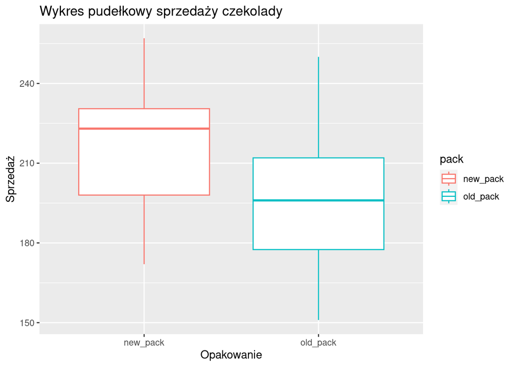

```r
ggplot(data=chocolate_df, aes(x=pack, y=sold, color=pack)) + geom_boxplot() + labs(title = "Wykres pudełkowy sprzedaży czekolady") + xlab("Opakowanie") + ylab("Sprzedaż")
```

Z powyższych wniosków oraz wykresu pudełkowego możemy powiedzieć, że przyjmujemy hipotezę zerową, że zarząd miał rację na temat wzrostu sprzedaży poprzez wprowadzenie nowych opakowań, na poziomie istotności $\alpha = 0.05$.

## Zadanie 3.

Treść:

Użyj metody bootstrap do wykonania powyższych testów i porównaj wyniki.

Rozwiązanie:

Dla zadania 1:

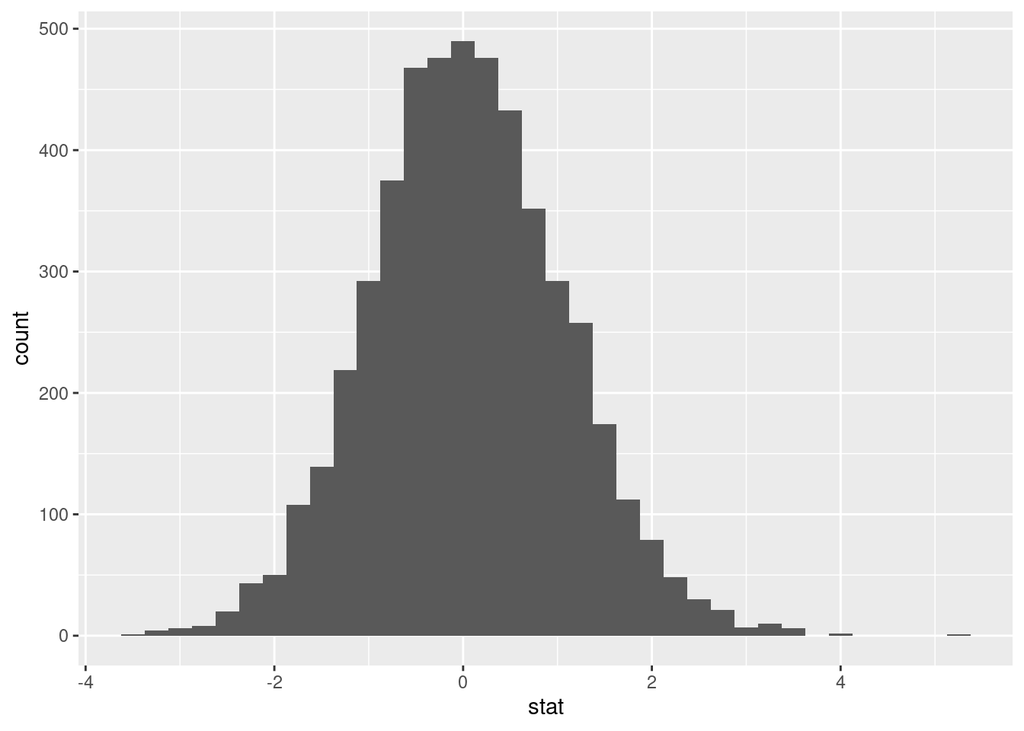

```r
bootstrap_durability <- zad2$durability - mean(zad2$durability) + 48
n <- length(zad2$durability)
bootstrap_stat <- rep(0,5000)

mu0 <- 48

compute_z <- function(sample,mu){
  se <- sqrt((1/(n-1))*sum((sample-mean(sample))^2))
  return((mean(sample)-mu)/((se)/sqrt(n)))
}

for(i in 1:5000){
  curr_sample <- sample(bootstrap_durability, size=n, replace=TRUE)
  bootstrap_stat[i] <- compute_z(curr_sample, mu0)
}

bootstrap_stat_tbl <- tibble(stat = bootstrap_stat)

ggplot(data = bootstrap_stat_tbl, aes(x = stat)) + geom_histogram(binwidth=0.25)
```

Możemy za pomocą metody bootstap sprawdzić $p-value$, które pokaże nam istotność naszej hipotezy zerowej. Musimy skorzystać tutaj z CTG:

Dzięki temu mamy:

```r
Z_sd <- sqrt((1/(n-1))*sum((zad2$durability-mean(zad2$durability))^2))
mu0 <- 48
Z_stat <- (mean(zad2$durability) - mu0)/(Z_sd/sqrt(n))

bootstrap_p <- sum((bootstrap_stat <= -abs(Z_stat))|(bootstrap_stat >= abs(Z_stat)))/5000

paste("p-value testu bootstrap wynosi", round(bootstrap_p,100))
```

```
## [1] "p-value testu bootstrap wynosi 0"
```

Widzimy również, że przybliżone $p-value$ również jest mniejsze niż ustalony poziom istotności $\alpha = 0.05$. Zatem możemy wnioskowac, że metoda bootstrap pomaga nam przybliżyć wyniki testu t-Studenta.

Dla zadania 2:

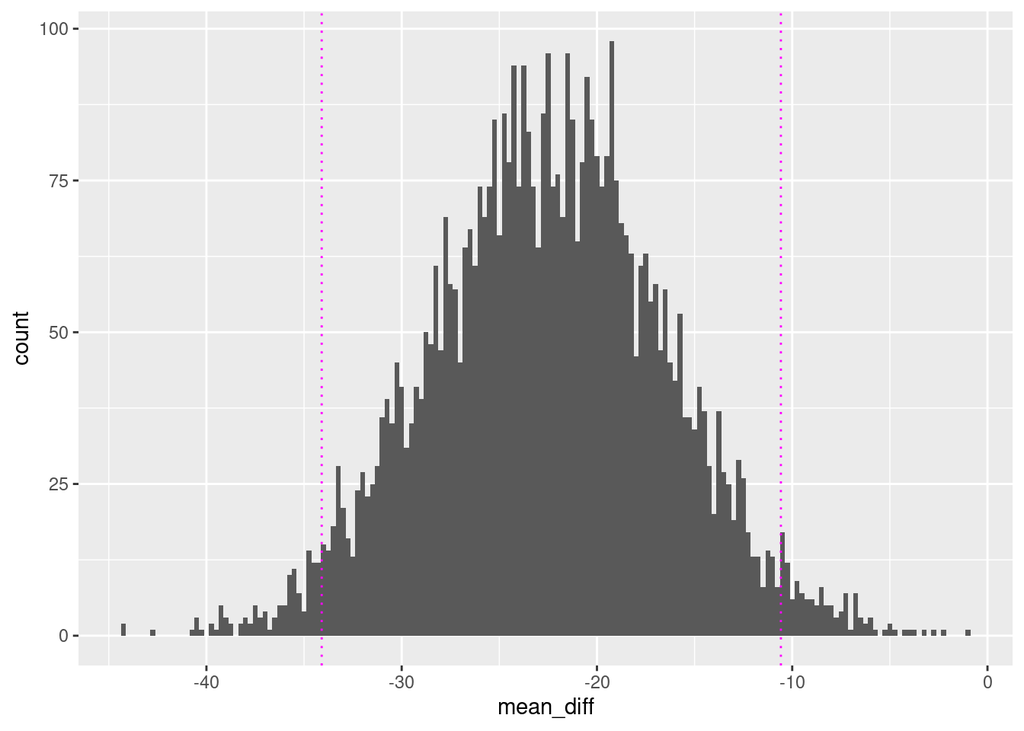

```r
n <- length(chocolate_df_trans$new_pack)

bootstrap_stat <- rep(0,5000)

for(i in 1:5000){
  curr_sample_1 <- sample(chocolate_df_trans$old_pack, size=n, replace=TRUE)
  curr_sample_2 <- sample(chocolate_df_trans$new_pack, size=n, replace=TRUE)
  bootstrap_stat[i] <- mean(curr_sample_1) - mean(curr_sample_2)
}
bootstrap_stat <- tibble(mean_diff = bootstrap_stat)

ggplot(bootstrap_stat, aes(x=mean_diff)) + geom_histogram(binwidth=0.25) + geom_vline(xintercept=c(quantile(bootstrap_stat$mean_diff, 0.025),quantile(bootstrap_stat$mean_diff, 0.975)), linetype='dotted', color='magenta')
```

Obszar zaznaczony różowymi liniami nie tylko reprezentuje obszar decyzyjny, ale również stanowi 95% przedział ufności na różnicę średnich w naszych próbach, który został uzyskany za pomocą metody bootstrap. Metoda bootstrap może być stosowana zawsze, przy odpowiednim dostosowaniu liczby prób bootstrap.

Jednak w przypadku testu t-Studenta, mamy również parametryczną formę przedziału ufności. W zadaniu drugim za pomocą testu t-Studenta uzyskaliśmy przedział ufności dla różnicy pomiedzy średnimi:

$(-34.51438 ; -10.58240)$.

Natomiast metodą bootstrap:

```r
quantile(bootstrap_stat$mean_diff,c(0.025,0.975))
```

```
##      2.5%     97.5%
## -34.09677 -10.58065
```

Widzimy, że oba przedziały są do siebie zbliżone, zatem metoda bootstrap przybliża wyniki z testu t-Studenta.

Dzięki zastosowaniu metody bootstrap w poprzednich zadaniach otrzymaliśmy analogiczne wyniki, co dowodzi, że niezależnie od wybranej metody dochodzimy do tego samego wyniku i możemy wyciągnąć podobne wnioski na temat danych próbek.